# Practical Machine Learning - Course Project

### Prediction Study: Clean Data Set

Before the data partitioning starts, I will remove the unnecessary variables. These unnecessary variables are defined as variables containing more than 70% of the NA placeholder values in the data set, and where they are considered near zero covariates (predictors).

```r
## Identifying variables to remove

require(caret)
nzv <- nearZeroVar(training, saveMetrics=TRUE)

### Near Zero Covariates are defined as not being unique, possibly because they contain a lot of zeros, or that they are binomial categories. In this case, I only removed the sensor variables that are mostly empty without data.

temp <- subset(training, select=-c(kurtosis_yaw_belt, skewness_yaw_belt, kurtosis_yaw_dumbbell, skewness_yaw_dumbbell, kurtosis_yaw_forearm, skewness_yaw_forearm))
temp2 <- subset(origintest, select=-c(kurtosis_yaw_belt, skewness_yaw_belt, kurtosis_yaw_dumbbell, skewness_yaw_dumbbell, kurtosis_yaw_forearm, skewness_yaw_forearm))

### Not all NAs can be defined through the Near Zero Covariates method. Further cleanup will be done on columns with NAs constituting 70% of the covariate (predictor).

names_train <- names(temp)
NA_train <- as.character()

for (i in names_train) {

        if((sum(is.na(temp[,i])) >= 0.7*nrow(temp))) {

        temp3 <- i
        NA_train <- c(NA_train, temp3)

}

}

names_test <- names(temp2)
NA_test <- as.character()

for (i in names_test) {

        if((sum(is.na(temp2[,i])) >= 0.7*nrow(temp2))) {

        temp4 <- i
        NA_test <- c(NA_test, temp4)

}


}

sort_train <- temp[,!(names(temp) %in% NA_train)]
sort_test <- temp2[,!(names(temp2) %in% NA_test)]

### Cleanup the Workspace

rm(temp, temp2, temp3, temp4, nzv, i, NA_train, NA_test)


### Checking if there are near zero covariates in the clean set

nzv <- nearZeroVar(sort_train, saveMetrics=TRUE)
nzv
```

```
##                      freqRatio percentUnique zeroVar   nzv
## X                     1.000000  100.00000000   FALSE FALSE
## user_name             1.100679    0.03057792   FALSE FALSE
## raw_timestamp_part_1  1.000000    4.26562022   FALSE FALSE
## raw_timestamp_part_2  1.000000   85.53154622   FALSE FALSE
## cvtd_timestamp        1.000668    0.10192641   FALSE FALSE
## new_window           47.330049    0.01019264   FALSE  TRUE
## num_window            1.000000    4.37264295   FALSE FALSE
## roll_belt             1.101904    6.77810621   FALSE FALSE
## pitch_belt            1.036082    9.37722964   FALSE FALSE
## yaw_belt              1.058480    9.97349913   FALSE FALSE
## total_accel_belt      1.063160    0.14779329   FALSE FALSE
## gyros_belt_x          1.058651    0.71348486   FALSE FALSE
## gyros_belt_y          1.144000    0.35164611   FALSE FALSE
## gyros_belt_z          1.066214    0.86127816   FALSE FALSE
## accel_belt_x          1.055412    0.83579655   FALSE FALSE
## accel_belt_y          1.113725    0.72877383   FALSE FALSE
## accel_belt_z          1.078767    1.52379982   FALSE FALSE
## magnet_belt_x         1.090141    1.66649679   FALSE FALSE
## magnet_belt_y         1.099688    1.51870350   FALSE FALSE
## magnet_belt_z         1.006369    2.32901845   FALSE FALSE
## roll_arm             52.338462   13.52563449   FALSE FALSE
## pitch_arm            87.256410   15.73234125   FALSE FALSE
## yaw_arm              33.029126   14.65701763   FALSE FALSE
## total_accel_arm       1.024526    0.33635715   FALSE FALSE
## gyros_arm_x           1.015504    3.27693405   FALSE FALSE
## gyros_arm_y           1.454369    1.91621649   FALSE FALSE
## gyros_arm_z           1.110687    1.26388747   FALSE FALSE
## accel_arm_x           1.017341    3.95984099   FALSE FALSE
## accel_arm_y           1.140187    2.73672409   FALSE FALSE
## accel_arm_z           1.128000    4.03628580   FALSE FALSE
## magnet_arm_x          1.000000    6.82397309   FALSE FALSE
## magnet_arm_y          1.056818    4.44399144   FALSE FALSE
## magnet_arm_z          1.036364    6.44684538   FALSE FALSE
## roll_dumbbell         1.022388   84.20650290   FALSE FALSE
## pitch_dumbbell        2.277372   81.74498012   FALSE FALSE
## yaw_dumbbell          1.132231   83.48282540   FALSE FALSE
## total_accel_dumbbell  1.072634    0.21914178   FALSE FALSE
## gyros_dumbbell_x      1.003268    1.22821323   FALSE FALSE
## gyros_dumbbell_y      1.264957    1.41677709   FALSE FALSE
## gyros_dumbbell_z      1.060100    1.04984201   FALSE FALSE
## accel_dumbbell_x      1.018018    2.16593619   FALSE FALSE
## accel_dumbbell_y      1.053061    2.37488533   FALSE FALSE
## accel_dumbbell_z      1.133333    2.08949139   FALSE FALSE
## magnet_dumbbell_x     1.098266    5.74864948   FALSE FALSE
## magnet_dumbbell_y     1.197740    4.30129447   FALSE FALSE
## magnet_dumbbell_z     1.020833    3.44511263   FALSE FALSE
## roll_forearm         11.589286   11.08959331   FALSE FALSE
## pitch_forearm        65.983051   14.85577413   FALSE FALSE
## yaw_forearm          15.322835   10.14677403   FALSE FALSE
## total_accel_forearm   1.128928    0.35674243   FALSE FALSE
## gyros_forearm_x       1.059273    1.51870350   FALSE FALSE
## gyros_forearm_y       1.036554    3.77637346   FALSE FALSE
## gyros_forearm_z       1.122917    1.56457038   FALSE FALSE
## accel_forearm_x       1.126437    4.04647844   FALSE FALSE
## accel_forearm_y       1.059406    5.11160942   FALSE FALSE
## accel_forearm_z       1.006250    2.95586586   FALSE FALSE
## magnet_forearm_x      1.012346    7.76679238   FALSE FALSE
## magnet_forearm_y      1.246914    9.54031189   FALSE FALSE
## magnet_forearm_z      1.000000    8.57710733   FALSE FALSE
## classe                1.469581    0.02548160   FALSE FALSE
```

### Prediction Study: Cross Validation & Algorithm Used

As the process can get long when passing more than 10000 observations through the training process, I shall do a 4-fold cross validation on the training set. This means, the main sample will be tested 4 times. Cross validation serves to increase accuracy of the model.

The new training and testing set will be created as `crosstrain` and `testing`. The percentage attributed will be 60% and 40% respectively, for a medium sample size.

Intuitively, sensor data of a particular variable is independent at the point of reading, therefore random. The non-linear nature of sensor data is evident in this data set. Therefore, linear models will not be used. If you use the caret (Classification and Regression Techniques) package, it immediately identifies a linear model and generalized linear model as the wrong model type for classification.

Principal Component Analysis will also not be used here, as every predictor represents a dimension of the sensor variable (e.g. x,y,z), which will not constitute to an accurate prediction if one dimension is missing. It is akin to taking a part of the sensor away, and still expecting the sensor to function properly.

3 separate prediction functions will be applied to each sub train and test set. modelFit 1, 2 and 3 will be created.

1. No pre-processing. The Classification Tree model will be applied on `crosstrain`.
2. No pre-processing. The Linear Discriminant Analysis model will then be applied on `crosstrain`. This assumes that the data can be explained by a probablistic approach using Bayes Theorem, and a function that characterises the data as a Gaussian distribution of same covariances.
3. No pre-processing. The Random Forest model will be applied on `crosstrain`. This prediction model is particularly useful in dealing with huge amounts of input variables. The idea behind Random Forest lies in:

   ```
   - Bootstrapping the sample
   - Splitting the variables into different groups, and bootstrapping these variables again
   - Multiple Decision Trees, and a voting cycle starts on which prediction is the best
   ```

```r
### K-Fold exists as an option in trainControl

set.seed(3000)
inTrain <- createDataPartition(y=sort_train$classe, p=0.60, list=F)
crosstrain <- sort_train[inTrain,]
testing <- sort_train[-inTrain,]
crosstrain <- crosstrain[,-c(1:7)]
testing <- testing[,-c(1:7)]

### Setting commands for 4-fold cross validation

foldControl <- trainControl(method="cv", number=4)

### Simulating the prediction, using Random Forests.

require(randomForest)
require(rpart)
set.seed(3001)
modelFit1 <- train(classe ~ ., method="rpart", trControl = foldControl, data=crosstrain)
set.seed(3001)
modelFit2 <- train(classe ~ ., method="lda", trControl = foldControl, data=crosstrain)
set.seed(3001)
modelFit3 <- train(classe ~ ., method="rf", trControl = foldControl, data=crosstrain)
```

### Evaluation

We shall go into evaluation of the specified 3 model fits. As a reminder of what the research strives to do, an extract is taken, as follows:

*Six young health participants were asked to perform one set of 10 repetitions of the Unilateral Dumbbell Biceps Curl in five different fashions: exactly according to the specification (Class A), throwing the elbows to the front (Class B), lifting the dumbbell only halfway (Class C), lowering the dumbbell only halfway (Class D) and throwing the hips to the front (Class E).*

*1st Method: Classification Tree*

```r
### Classification Tree

require(rattle)
```

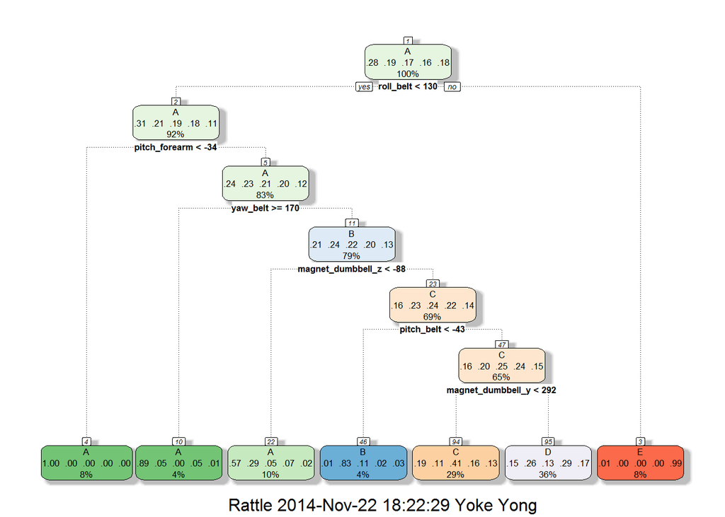

```r
require(rpart.plot)
fancyRpartPlot(modelFit1$finalModel)
```

Lets do a prediction using modelFit1.

```r
predictor1 <- predict(modelFit1, newdata = testing[,-53])
confusionMatrix(testing$classe, predictor1)
```

```
## Confusion Matrix and Statistics
##
##           Reference
## Prediction    A    B    C    D    E
##          A 1369    5  445  407    6
##          B  249  271  265  733    0
##          C   39   21  911  397    0
##          D   78   11  373  824    0
##          E   22    6  258  493  663
##
## Overall Statistics
##
##                Accuracy : 0.5147
##                  95% CI : (0.5035, 0.5258)
##     No Information Rate : 0.3638
##     P-Value [Acc > NIR] : < 2.2e-16
##
##                   Kappa : 0.3958
##  Mcnemar's Test P-Value : < 2.2e-16
##
## Statistics by Class:
##
##                      Class: A Class: B Class: C Class: D Class: E
## Sensitivity            0.7792  0.86306   0.4045   0.2887  0.99103
## Specificity            0.8583  0.83444   0.9183   0.9075  0.89146
## Pos Pred Value         0.6134  0.17852   0.6659   0.6407  0.45978
## Neg Pred Value         0.9309  0.99320   0.7930   0.6905  0.99906
## Prevalence             0.2239  0.04002   0.2870   0.3638  0.08527
## Detection Rate         0.1745  0.03454   0.1161   0.1050  0.08450
## Detection Prevalence   0.2845  0.19347   0.1744   0.1639  0.18379
## Balanced Accuracy      0.8187  0.84875   0.6614   0.5981  0.94125
```

As from the confusion matrix, an accuracy of only 51.47%, which is not satisfactory. Therefore, prediction with Classification Tree Models will be dropped.

*2nd Method: Linear Discriminant Analysis*

```r
modelFit2
```

```
## Linear Discriminant Analysis
##
## 11776 samples
##    52 predictor
##     5 classes: 'A', 'B', 'C', 'D', 'E'
##
## No pre-processing
## Resampling: Cross-Validated (4 fold)
##
## Summary of sample sizes: 8831, 8832, 8833, 8832
##
## Resampling results
##
##   Accuracy  Kappa  Accuracy SD  Kappa SD
##   0.701     0.621  0.00663      0.0086
##
##
```

We can see that the accuracy of the fit lies on 70.1%. Let’s do a prediction with this model.

```r
predictor2 <- predict(modelFit2, newdata=testing[,-53])
confusionMatrix(testing$classe, predictor2)
```

```
## Confusion Matrix and Statistics
##
##           Reference
## Prediction    A    B    C    D    E
##          A 1796   61  205  161    9
##          B  237  963  192   49   77
##          C  140  107  925  153   43
##          D   69   59  169  944   45
##          E   48  229  123  164  878
##
## Overall Statistics
##
##                Accuracy : 0.7018
##                  95% CI : (0.6915, 0.7119)
##     No Information Rate : 0.2919
##     P-Value [Acc > NIR] : < 2.2e-16
##
##                   Kappa : 0.6228
##  Mcnemar's Test P-Value : < 2.2e-16
##
## Statistics by Class:
##
##                      Class: A Class: B Class: C Class: D Class: E
## Sensitivity            0.7843   0.6786   0.5731   0.6417   0.8346
## Specificity            0.9215   0.9136   0.9289   0.9464   0.9170
## Pos Pred Value         0.8047   0.6344   0.6762   0.7341   0.6089
## Neg Pred Value         0.9120   0.9279   0.8936   0.9197   0.9728
## Prevalence             0.2919   0.1809   0.2057   0.1875   0.1341
## Detection Rate         0.2289   0.1227   0.1179   0.1203   0.1119
## Detection Prevalence   0.2845   0.1935   0.1744   0.1639   0.1838
## Balanced Accuracy      0.8529   0.7961   0.7510   0.7940   0.8758
```

The accuracy, in this case, is 70.18%. It is still not satisfactory, therefore we will not go with the Linear Discriminant Analysis Model as the prediction function.

*3rd Method: Random Forests*

```r
modelFit3
```

```
## Random Forest
##
## 11776 samples
##    52 predictor
##     5 classes: 'A', 'B', 'C', 'D', 'E'
##
## No pre-processing
## Resampling: Cross-Validated (4 fold)
##
## Summary of sample sizes: 8831, 8832, 8833, 8832
##
## Resampling results across tuning parameters:
##
##   mtry  Accuracy  Kappa  Accuracy SD  Kappa SD
##    2    0.989     0.986  0.00162      0.00206
##   27    0.989     0.985  0.00392      0.00497
##   52    0.983     0.979  0.00640      0.00810
##
## Accuracy was used to select the optimal model using  the largest value.
## The final value used for the model was mtry = 2.
```

Accuracy is the highest, at 98.9%, when 2 random sampled variables are used at each split in the random forest approach. No further tuning is done to the “mtry” parameter as it is obvious from the table that the higher “mtry” gets, the lower the accuracy goes. We shall do a prediction with this approach:

```r
predictor3 <- predict(modelFit3, newdata=testing[,-53])
confusionMatrix(testing$classe, predictor3)
```

```
## Confusion Matrix and Statistics
##
##           Reference
## Prediction    A    B    C    D    E
##          A 2230    2    0    0    0
##          B   20 1497    1    0    0
##          C    0    7 1360    1    0
##          D    0    0   33 1250    3
##          E    0    0    1    4 1437
##
## Overall Statistics
##
##                Accuracy : 0.9908
##                  95% CI : (0.9885, 0.9928)
##     No Information Rate : 0.2868
##     P-Value [Acc > NIR] : < 2.2e-16
##
##                   Kappa : 0.9884
##  Mcnemar's Test P-Value : NA
##
## Statistics by Class:
##
##                      Class: A Class: B Class: C Class: D Class: E
## Sensitivity            0.9911   0.9940   0.9749   0.9960   0.9979
## Specificity            0.9996   0.9967   0.9988   0.9945   0.9992
## Pos Pred Value         0.9991   0.9862   0.9942   0.9720   0.9965
## Neg Pred Value         0.9964   0.9986   0.9946   0.9992   0.9995
## Prevalence             0.2868   0.1919   0.1778   0.1600   0.1835
## Detection Rate         0.2842   0.1908   0.1733   0.1593   0.1832
## Detection Prevalence   0.2845   0.1935   0.1744   0.1639   0.1838
## Balanced Accuracy      0.9954   0.9954   0.9868   0.9953   0.9986
```

Overall accuracy is of 99.08%. Therefore, we will go with the Random Forest Prediction Model. The out-of-sample error is 0.92%.

### Best Prediction Model: Random Forests

We now know that Random Forests is indeed a good approach in getting the accuracy we desire. Now, I shall apply this to the original test set, `sort_test`.

The prediction results are as follows:

```r
### Applying the best model fit to the original testing data, sort_test

set.seed(3001)
sort_test2 <- sort_test[,-c(1:7)]
predictor0 <- predict(modelFit3, newdata=sort_test2[,-53])
predictor0 <- as.character(predictor0)
print(predictor0)
```

```
##  [1] "B" "A" "B" "A" "A" "E" "D" "B" "A" "A" "B" "C" "B" "A" "E" "E" "A"
## [18] "B" "B" "B"
```